# Academic Paper in Markdown

Some ideas for those looking to start writing academica abstracts in RMarkdown.

Ive included some examples of forms you can use for yourself both without anything extra and with YAML alterations that need a .lua file.

## Here is a sample of the basic YAML format

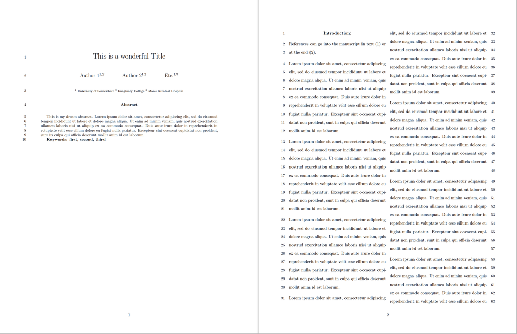

Basic Yaml

## Here is a sample of the augmented YAML format

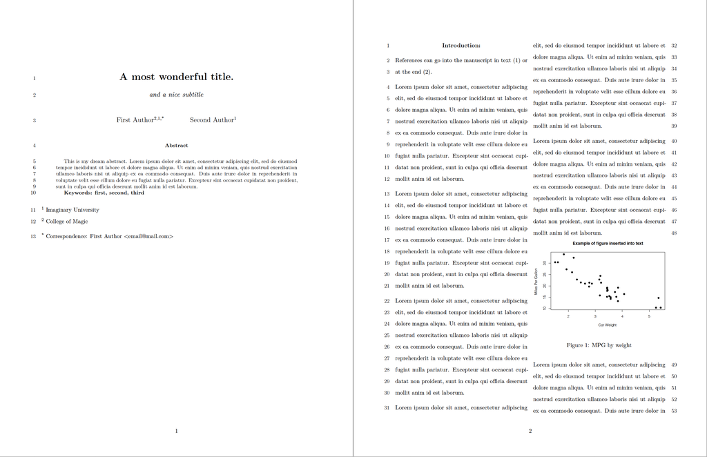

Augmented Yaml

Ill work on this as I learn more. Im really new at this so if there are changes that can improve these please let me know.

Things Ive Included:

Tables in landscape two ways, both included after the references

In text figures and figures after the reference section

Things im still learning how to do

Include in text DAG or DAG at the end of a document; will likely require me learning TikzDevice

Learning how to get a table to insert correctly in text with two column format

Figure out how to get the tables to render appropriately when knitted to word-the tables currently only work when knitted to PDF

…more to come.